# Множественная регрессия

## Множественная регрессия

### Вы сможете

- Подобрать модель множественной линейной регрессии
- Протестировать ее статистическую значимость и валидность

## Пример: птицы в лесах Австралии

Фрагментация лесных местообитаний - одна из важнейших проблем Австралии. От каких характеристик лесного участка зависит обилие птиц во фрагментированных лесных массивах? (Loyn, 1987)

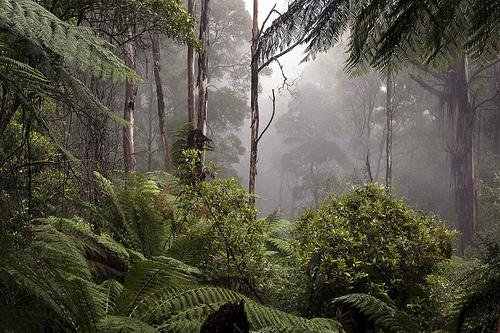

Mystic Forest - Warburton, Victoria by ¡kuba! on flickr

56 лесных участков:

- ABUND - обилие птиц
- AREA - площадь участка
- YRISOL - год изоляции участка
- DIST - расстояние до ближайшего леса
- LDIST - расстояние до ближайшего большого леса
- GRAZE - пастбищная нагрузка (1-5)
- ALT - высота над уровнем моря

Пример из кн. Quinn, Keugh, 2002, данные из Loyn, 1987)

## Читаем данные

```r
bird <- read.table("data/loyn.csv", sep = ",", header = TRUE)
```

Все ли правильно открылось?

```r
str(bird)
```

```
## 'data.frame':    56 obs. of  7 variables:
##  $ ABUND : num  5.3 2 1.5 17.1 13.8 14.1 3.8 2.2 3.3 3 ...
##  $ AREA  : num  0.1 0.5 0.5 1 1 1 1 1 1 1 ...
##  $ YRISOL: int  1968 1920 1900 1966 1918 1965 1955 1920 1965 1900 ...
##  $ DIST  : int  39 234 104 66 246 234 467 284 156 311 ...
##  $ LDIST : int  39 234 311 66 246 285 467 1829 156 571 ...
##  $ GRAZE : int  2 5 5 3 5 3 5 5 4 5 ...
##  $ ALT   : int  160 60 140 160 140 130 90 60 130 130 ...
```

Есть ли пропущенные значения?

```r
colSums(is.na(bird))
```

```
##  ABUND   AREA YRISOL   DIST  LDIST  GRAZE    ALT
##      0      0      0      0      0      0      0
```

## Можно ли ответить на вопрос таким методом?

```r
cor(bird)
```

```
##          ABUND     AREA   YRISOL   DIST   LDIST  GRAZE    ALT
## ABUND   1.0000  0.25597  0.50336  0.236  0.0872 -0.683  0.386
## AREA    0.2560  1.00000 -0.00149  0.108  0.0346 -0.310  0.388
## YRISOL  0.5034 -0.00149  1.00000  0.113 -0.0833 -0.636  0.233
## DIST    0.2361  0.10834  0.11322  1.000  0.3172 -0.256 -0.110
## LDIST   0.0872  0.03458 -0.08332  0.317  1.0000 -0.028 -0.306
## GRAZE  -0.6825 -0.31040 -0.63557 -0.256 -0.0280  1.000 -0.407
## ALT     0.3858  0.38775  0.23272 -0.110 -0.3060 -0.407  1.000
```

- Нет
- Обычная корреляция не учитывает, что взаимосвязь между переменными может находиться под контролем других переменных и их взаимодействий.
- Множественные тесты. При тестировании значимости множества коэффициентов корреляции нужно вводить поправку для уровня значимости. Лучше было бы учесть все в одном анализе.

## Нам предстоит построить модель множественной линейной регрессии

\[y_i = b_0 + b_1x_{1i} + b_2x_{2i} + b_3x_{3i} + ... + b_{p - 1}x_{p - 1\;i} + e_i\]

- \(y_i\) — значение зависимой переменной для \(i\)-того наблюдения
- \(b_0\) — свободный член (intercept). Значение \(y\) при \(x_1 = x_2 = x_3= \ldots = x_{p - 1} = 0\)
- \(b_1\) — частный угловой коэффициент для зависимости \(y\) от \(x_1\). Показывает, на сколько единиц изменяется \(y\) при изменении \(x_1\) на одну единицу и при условии, что все остальные предикторы не изменяются \(b_2\), \(b_3\), …., \(b_{p - 1}\) — аналогично
- \(e_i\) — варьирование \(y\), не объясненное данной моделью
- \(p\) — число параметров модели

## Геометрическая интерпретация множественной линейной модели

### Для случая с одним предиктором \(y_i = b_0 + b_1x_{1i} + e_i\) — линия регрессии

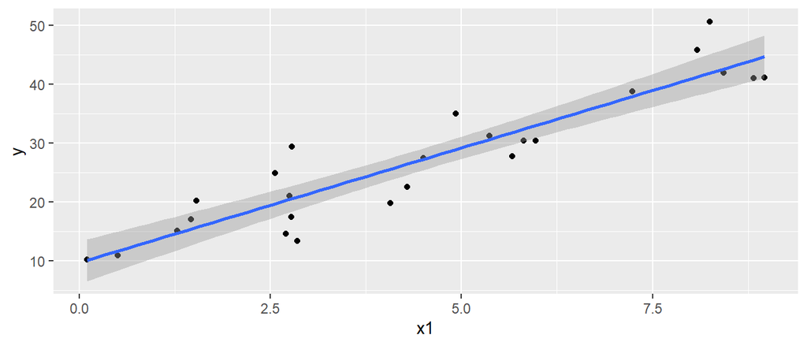

## Геометрическая интерпретация множественной линейной модели

### Для случая с двумя предикторами \(y_i = b_0 + b_1x_{1i} + b_2x_{2i} + e_i\) — плоскость в трехмерном пространстве

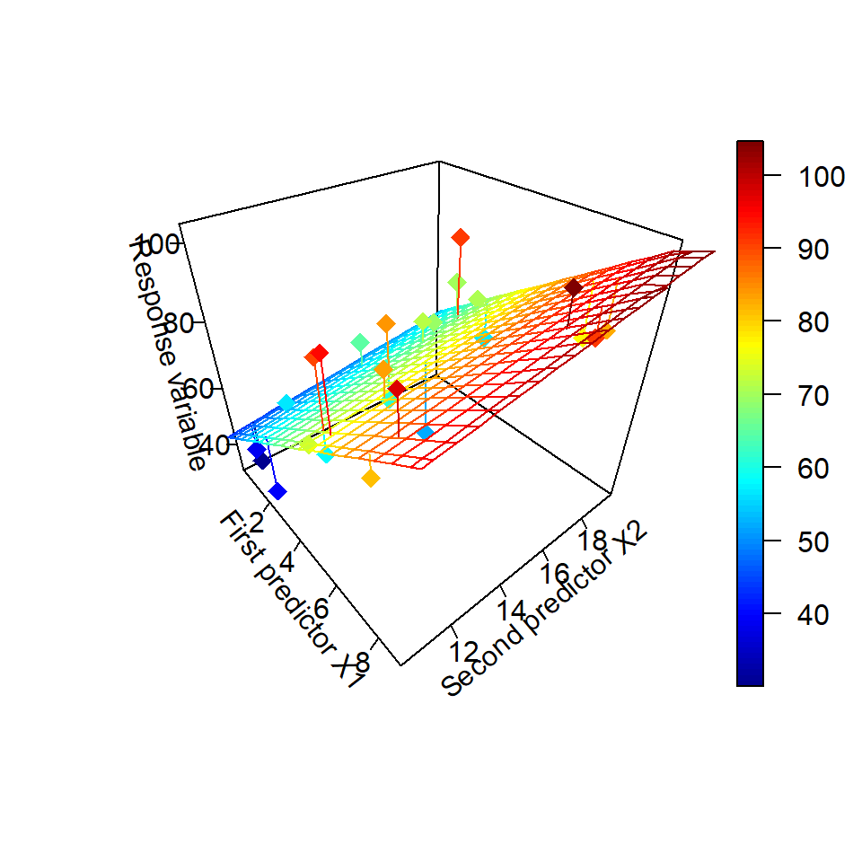

## Геометрическая интерпретация множественной линейной модели

### Для случая с большим количеством предикторов

\[y_i = b_0 + b_1x_{1i} + b_2x_{2i} + b_3x_{3i} + ... + b_{p - 1}x_{p - 1\;i} + e_i\]

Плоскость в n-мерном пространстве, оси которого образованы значениями предикторов

## Перобразование предикторов

```r
# Трансформируем переменные
bird$logAREA <- log(bird$AREA)
bird$logDIST <- log(bird$DIST)
bird$logLDIST <- log(bird$LDIST)
```

Это нужно так как некоторые значения сильно отскакивают от остальных (влиятельные наблюдения)

## Модель, которую мы хотим подобрать

\[\begin{aligned}{ABUND}_i &= b_0 + b_1 \cdot logAREA_i + b_2 \cdot YRISOL_i + \\ &+ b_3 \cdot logDIST_i + b_4 \cdot logLDIST_i + b_5 \cdot GRAZE_i + b_6 \cdot ALT_i + e_i\\ \end{aligned}\]

Возможно, что эту модель придется изменить.

В начале нам нужно убедиться, что условия применимости линейной регрессии выполняются.

## Вспомним условия применимости линейной регрессии

- Линейная связь между зависимой переменной (\(Y\)) и предикторами (\(X\))
- Независимость значений \(Y\) друг от друга
- Нормальное распределение \(Y\) для каждого уровня значений \(X\)
- Гомогенность дисперсий \(Y\) для каждого уровня значений \(X\)
- **Отсутствие коллинеарности предикторов (для можественной регрессии)**

## Мультиколлинеарность

## Мультиколлинеарность

Мультиколлинеарность — наличие линейной зависимости между независимыми переменными (предикторами) в регрессионной модели.

При наличии мультиколлинеарности оценки параметров неточны, а значит сложно интерпретировать влияние предикторов на отклик.

### Косвенные признаки мультиколлинеарности:

- Большие ошибки оценок параметров
- Большинство значений параметров модели незначимо отличается от нуля, но F критерий говорит, что модель в целом значима.

### Проверка на мультиколлинеарность

- Коэффициент раздутия дисперсии (Variance inflation factor, VIF).

## Как рассчитывается VIF

Пусть наша модель \(y_i = b_0 + b_1 x_{1i} + b_2 x_{2i} + \ldots + b_{p - 1} x_{p - 1\;i} + e_i\).

Нужно оценить какую долю изменчивости конкретного предиктора могут объяснить другие предикторы (т.е. насколько предикторы независимы).

Для каждого предиктора:

1. Строим регрессионную модель данного предиктора от всех остальных: \[x_1 = c_0 + c_1x_2 +c_2x_3 + .... + c_{p - 2}x_{p - 1}\]
2. Находим \(R^2\) этой модели.
3. Вычисляем коэффициент раздутия дисперсии: \[VIF = \frac{1}{1-R^2}\]

## Мультиколлинеарность опасна

В случае наличия мультиколлинеарности:

- Оценки коэффициентов модели нестабильны (даже могут менять знак при небольших изменениях модели или исходных данных).
- Стандартные ошибки оценок параметров увеличатся в \(\sqrt{VIF}\) раз.
- В результате меньше шансов заметить влияние предиктора, т.к. уровень значимости (p-value) в тестах будет выше.

## Как бороться с мультиколлинеарностью?

- Можно последовательно удалить из модели избыточные предикторы с VIF > 2
  1. подбираем модель
  2. считаем VIF
  3. удаляем предиктор с самым большим VIF
  4. повторяем 1-3

## Задание

- Постройте множественную линейную регрессию для зависимости обилия птиц (`ABUND`) от других переменных (`logAREA`, `YRISOL`, `logDIST`, `logLDIST`, `GRAZE`, `ALT`)

\[\begin{aligned}{ABUND}_i &= b_0 + b_1 \cdot logAREA_i + b_2 \cdot YRISOL_i + \\ &+ b_3 \cdot logDIST_i + b_4 \cdot logLDIST_i + b_5 \cdot GRAZE_i + b_6 \cdot ALT_i + e_i\\ \end{aligned}\]

- Используйте функцию `vif()`, чтобы проверить, коллинеарны ли предикторы.

Дополните код:

```r
mod1 <- lm(formula = , data = )
vif()
```

## Решение

```r
# Строим модель
mod1 <- lm(formula = ABUND ~  logAREA + YRISOL + logDIST + logLDIST + GRAZE + ALT,
           data = bird)
# Проверяем, есть ли коллинеарность?
vif(mod1)
```

```
##  logAREA   YRISOL  logDIST logLDIST    GRAZE      ALT
##     1.91     1.80     1.65     2.01     2.52     1.47
```

В нашей модели сильной мультиколлинеарности нет.

Однако, возможно `GRAZE` — избыточный предиктор.

## Удалим из модели избыточный предиктор

```r
mod2 <- update(mod1, . ~ . -GRAZE)
vif(mod2)
```

```
##  logAREA   YRISOL  logDIST logLDIST      ALT
##     1.62     1.20     1.62     2.01     1.35
```

Теперь мультиколлинеарности нет. В модели осталось пять предикторов (и шесть параметров).

\[\begin{aligned}{ABUND}_i &= b_0 + b_1 \cdot logAREA_i + b_2 \cdot YRISOL_i + \\ &+ b_3 \cdot logDIST_i + b_4 \cdot logLDIST_i + b_5 \cdot ALT_i + e_i\\ \end{aligned}\]

## Уравнение модели

\[\begin{aligned}{ABUND}_i &= b_0 + b_1 \cdot logAREA_i + b_2 \cdot YRISOL_i + \\ &+ b_3 \cdot logDIST_i + b_4 \cdot logLDIST_i + b_5 \cdot ALT_i + e_i\\ \end{aligned}\]

Мы подобрали коэффициенты и можем записать уравнение модели.

```r
coef(mod2)
```

```
## (Intercept)     logAREA      YRISOL     logDIST    logLDIST
##   -226.0006      3.6882      0.1207     -0.1033     -0.3281
##         ALT
##      0.0318
```

\[\begin{aligned}{ABUND}_i &= -226.00 + 3.69 \cdot logAREA_i + 0.12 \cdot YRISOL_i - \\ &-0.10 \cdot logDIST_i -0.33 \cdot logLDIST_i + 0.03 \cdot ALT_i + e_i\\ \end{aligned}\]

## Задание

Проверьте, выполняются ли условия применимости для модели `mod2`. Дополните код:

```r
library()
mod2_diag <- data.frame(fortify(), $GRAZE)
# 1) График расстояния Кука
ggplot(data = , aes(x = 1:, y = .cooksd)) + geom_bar(stat = "")
# 2) График остатков от предсказанных значений
gg_resid <- ggplot(data = , aes(x = , y = )) + geom_point() + geom_hline()
gg_resid
# 3) Графики остатков от предикторов в модели и нет
res_1 <- gg_resid + aes(x = logAREA)
res_1
res_2 <- gg_resid
res_3 <- gg_resid
res_4 <- gg_resid
res_5 <- gg_resid
res_6 <- gg_resid
# все графики вместе
library(gridExtra)
grid.arrange(res_1, res_2, nrow = 2)
# 4) Квантильный график остатков
library(car)
qq
```

## Решение

### График остатков от предсказанных значений

- Выбросов нет
- Гетерогенность дисперсии?
- Два наблюдения с очень большими предсказанными значениями и большими остатками. Хорошо бы проверить их.

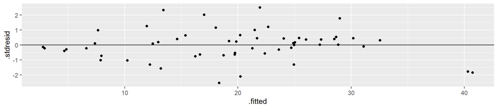

```r
mod2_diag <-  fortify(mod2)

gg_resid <- ggplot(data = mod2_diag, aes(x = .fitted, y = .stdresid)) +
  geom_point() + geom_hline(yintercept = 0)
gg_resid
```

## Решение

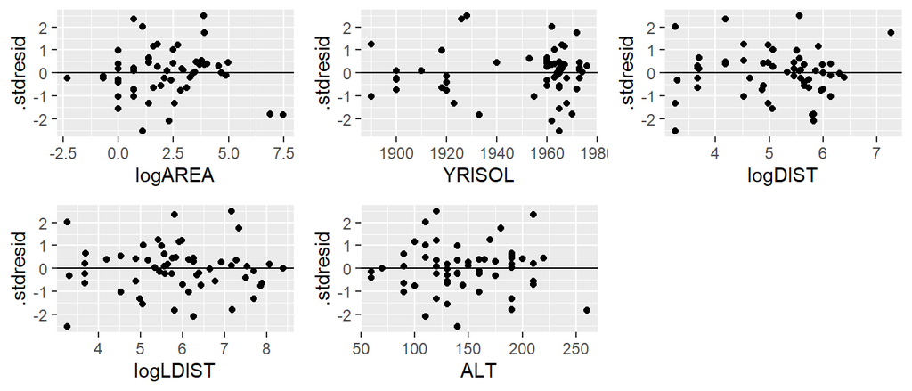

## Решение

```r
res_1 <- gg_resid + aes(x = logAREA)
res_2 <- gg_resid + aes(x = YRISOL)
res_3 <- gg_resid + aes(x = logDIST)
res_4 <- gg_resid + aes(x = logLDIST)
res_6 <- gg_resid + aes(x = ALT)

library(gridExtra)
grid.arrange(res_1, res_2, res_3, res_4,
              res_6, nrow = 2)
```

## Решение

### Квантильный график остатков

- Отклонения от нормального распределения остатков незначительны

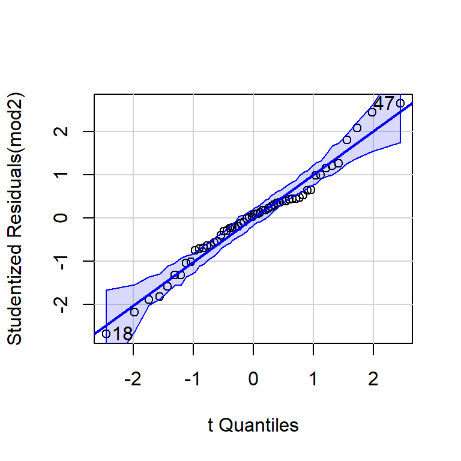

```
## [1] 18 47
```

```r
library(car)
qqPlot(mod2)
```

## Описание множественной линейной регрессии

- Записываем уравнение модели.
- Общую значимость модели оцениваем при помощи *F*-критерия.
- Качество подгонки модели описываем при помощи коэффициента детерминации с поправкой (\(R^2_{adj.}\)).
- При обсуждении значимости отдельных предикторов можно привести таблицу с оценками коэффициентов и тестами их значимости.
- При сравнении влияния отдельных предикторов приводим стандартизованные коэффициенты
- Приводим график предсказаний модели

## Что почитать

- Гланц, С., 1998. Медико-биологическая статистика. М., Практика
- Кабаков Р.И. R в действии. Анализ и визуализация данных на языке R. М.: ДМК Пресс, 2014
- Diez, D.M., Barr, C.D. and Çetinkaya-Rundel, M., 2015. OpenIntro Statistics. OpenIntro.
- Zuur, A., Ieno, E.N. and Smith, G.M., 2007. Analyzing ecological data. Springer Science & Business Media.
- Quinn G.P., Keough M.J. 2002. Experimental design and data analysis for biologists
- Logan M. 2010. Biostatistical Design and Analysis Using R. A Practical Guide